# Predictive Text Slide Deck

Mark Edney

22/05/2021

# Predictive Text Application

The Predictive Text Application accepts text from the user and predicts the next word from five different models: the Maximum Likeliness Estimate, Add One, Good Turing estimate, Absolute Discounting Interpolation and Kneser Ney Smoothing. These models perform automatic “Stupid Back-off” so the used n-gram is displayed on the side panel. The predictions are summarized in a table while the distributions for the models are displayed in column charts with the words summarized around their first character.

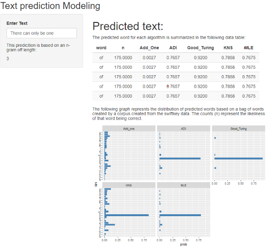

Appplication Sample

# Corpus Prepossessing

The corpus incorporates the following features:

- 10% sample of the data files
- Profanity filter
- English dictionary filter
- Contractions were included
- Stored as a binary file (RDS file)

```r
blog <- read_lines("~/R/Capestone/data/final/en_US/en_US.blogs.txt")
news <- read_lines("~/R/Capestone/data/final/en_US/en_US.news.txt")
twitter <- read_lines("~/R/Capestone/data/final/en_US/en_US.twitter.txt")
blog <- tibble(text = blog)
news <- tibble(text = news)
twitter <- tibble(text = twitter)

set.seed(90210)
corpus <- bind_rows(blog,twitter,news) %>%
        slice_sample(prop = 0.10) %>%
        mutate(line = row_number())
```

# N-grams

A unigram Data Frame was created from the sampled Corpus file. These unigrams were filtered and than the corpus was reconstructed by the line numbers.

```r
voc <- bind_rows(english, contract) %>% anti_join(prof)

unigram <- corpus %>% unnest_tokens(ngram, text, token = "ngrams", n = 1) %>%
        semi_join(voc, by = c("ngram"="word")
```

N-grams of higher level are easily created. Due to the size on the n-grams, the final n-grams were weighted to the lower levels. This was done with the quantile function evaluating the n-gram counts.

```r
unigram <- readRDS("unigram10.rds")
bigram <- readRDS("bigram10.rds")
trigram <- readRDS("trigram10.rds") %>% filter(n>quantile(.$n, 0.5))
tetragram <- readRDS("tetragram10.rds") %>% filter(n>quantile(.$n, 0.55))
pentagram <- readRDS("pentagram10.rds") %>% filter(n>quantile(.$n, 0.6))
hexagram <- readRDS("hexagram10.rds") %>% filter(n>quantile(.$n, 0.65)
```

# Extra features

The model includes some additional features such as the ability to handle unknown words. This was achieved by changing a sample of the most infrequent words to “unk”. When the user input includes a word not in the application vocabulary, it is changed to “unk”.

```r
unk <- unigramcount %>%
        filter(n==1) %>%
        slice_sample(n = mean(unigramcount$n))
unigram[unigram$ngram %in% unk$ngram,]$ngram <- "unk"
```

The application also includes code enabling the automatic “Stupid Back-off” in which the highest level off n-gram is used that is available. This value is based on the order of n-grams available as well as the length of the input text.

```r
n <- maxngram
        for (i in 2:n){
                if(i>5){ngrams.tbl[[i]] <- ngrams.tbl[[i]] %>%
                                filter(.[,i-5] == text$word[nrow(text)-4])}
                if(i>4){ngrams.tbl[[i]] <- ngrams.tbl[[i]] %>%
                                filter(.[,i-4] == text$word[nrow(text)-3])}
                if(i>3){ngrams.tbl[[i]] <- ngrams.tbl[[i]] %>%
                                filter(.[,i-3] == text$word[nrow(text)-2])}
                if(i>2){ngrams.tbl[[i]] <- ngrams.tbl[[i]] %>%
                                filter(.[,i-2] == text$word[nrow(text)-1])}
                ngrams.tbl[[i]] <- ngrams.tbl[[i]] %>%
                        filter(.[,i-1] == text$word[nrow(text)]) %>%
                                arrange(desc(n))}
```

# Model Performance

The models were tested by measuring the Perplexity which is a measure of the predictive power of a probability distribution. N represents the number of words.
$$PP(W) = 2^{\frac{1}{N}\Sigma^N_{i=1}log(p_i) }$$
Theses models were tested against testing sample of 500 lines not in the training sample where each following word was predicted. In total there were 11149 test samples.

```r
mdl.perplex %>% colMeans
```

```
##         MLE     Add_One Good_Turing         ADI         KNS
##         Inf    2401.795 2819552.122   60320.323   12711.404
```

```r
mdl.acc %>% colMeans
```

```
##   MLE_acc   ADD_acc    GT_acc   ADI_acc   KNS_acc
## 0.1599247 0.1589380 0.1575029 0.1596556 0.1577720
```